# Starbucks Food Menu Nutritional Analysis

## Starbucks Food Menu Nutritional Analysis and Optimization

[Generated by Datably.ai](https://Datably.ai)

01:39 07-18-2025

### Background & Goal:

The data: starbucks food menu nutrition. the question to answer: Menu Category Optimization: How do different food categories compare nutritionally? You have distinct categories (bagels, croissants, muffins, scones, cookies, danish). Investigate: Which categories offer the best nutritional value per calorie? Average macronutrient profiles by food type (are all croissants high-fat? all bagels high-carb?). Identify the "healthiest" and "least healthy" categories based on multiple criteria, Compare portion standardization across categories

### Step 1. Categorize Starbucks menu items by nutrition

Read the data file and print a small part of it. The file 'starbucks_menu_nutrition_food.csv' is in the current folder. These columns are numeric variables: 'Calories', 'Fat_g', 'Carb_g', 'Fiber_g', and 'Protein_g'. First 5 rows of data: Item Calories Fat_g Carb_g Fiber_g Protein_g Chonga Bagel 300 5 50 3 12 8-Grain Roll 380 6 70 7 10 Almond Croissant 410 22 45 3 10 Apple Fritter 460 23 56 2 7 Banana Nut Bread 420 22 52 2 6. Categorize the items the best you can by creating a new column called 'category'

```r
pacman::p_load(dplyr)
pacman::p_load(stringr)

df <- read.csv("starbucks_menu_nutrition_food.csv", stringsAsFactors = FALSE)
head(df, 5)
```

```
##               Item Calories Fat_g Carb_g Fiber_g Protein_g
## 1     Chonga Bagel      300     5     50       3        12
## 2     8-Grain Roll      380     6     70       7        10
## 3 Almond Croissant      410    22     45       3        10
## 4    Apple Fritter      460    23     56       2         7
## 5 Banana Nut Bread      420    22     52       2         6
```

```r
df <- df %>%
  mutate(category = case_when(
    str_detect(tolower(Item), "bagel") ~ "Bagel",
    str_detect(tolower(Item), "croissant") ~ "Croissant",
    str_detect(tolower(Item), "muffin") ~ "Muffin",
    str_detect(tolower(Item), "scone") ~ "Scone",
    str_detect(tolower(Item), "cookie") ~ "Cookie",
    str_detect(tolower(Item), "danish") ~ "Danish",
    str_detect(tolower(Item), "cake") ~ "Cake",
    str_detect(tolower(Item), "brownie") ~ "Brownie",
    str_detect(tolower(Item), "yogurt") ~ "Yogurt",
    str_detect(tolower(Item), "bar") ~ "Bar",
    str_detect(tolower(Item), "sandwich") ~ "Sandwich",
    str_detect(tolower(Item), "salad") ~ "Salad",
    str_detect(tolower(Item), "wrap") ~ "Wrap",
    str_detect(tolower(Item), "panini") ~ "Panini",
    str_detect(tolower(Item), "protein box") ~ "Protein Box",
    TRUE ~ "Other"
  ))

head(df, 5)
```

```
##               Item Calories Fat_g Carb_g Fiber_g Protein_g  category
## 1     Chonga Bagel      300     5     50       3        12     Bagel
## 2     8-Grain Roll      380     6     70       7        10     Other
## 3 Almond Croissant      410    22     45       3        10 Croissant
## 4    Apple Fritter      460    23     56       2         7     Other
## 5 Banana Nut Bread      420    22     52       2         6     Other
```

```r
df$category <- as.factor(df$category)
summary(df)
```

```
##      Item              Calories         Fat_g           Carb_g
##  Length:113         Min.   : 90.0   Min.   : 0.00   Min.   : 5.00
##  Class :character   1st Qu.:280.0   1st Qu.: 9.00   1st Qu.:31.00
##  Mode  :character   Median :360.0   Median :17.00   Median :42.00
##                     Mean   :356.6   Mean   :16.35   Mean   :41.49
##                     3rd Qu.:450.0   3rd Qu.:23.00   3rd Qu.:53.00
##                     Max.   :650.0   Max.   :37.00   Max.   :80.00
##
##     Fiber_g        Protein_g         category
##  Min.   : 0.00   Min.   : 1.00   Other   :25
##  1st Qu.: 1.00   1st Qu.: 5.00   Sandwich:19
##  Median : 2.00   Median : 8.00   Cake    :10
##  Mean   : 2.85   Mean   :11.47   Cookie  :10
##  3rd Qu.: 3.00   3rd Qu.:19.00   Bagel   : 9
##  Max.   :21.00   Max.   :34.00   Salad   : 7
##                                  (Other) :33
```

### Step 2. Create broad_category from specific food categories

Based on the unique factor values in the new 'category' column, create ANOTHER column called broad_category which sorts these into 4-5 wider range buckets to compare the foods within broader categories. Foer example, combine categories cookie, brownie, cake into 'sweets', combine croissant, muffin, scone, danish into 'pastries' , etc.

```r
pacman::p_load(dplyr)

df <- df %>%
  mutate(broad_category = case_when(
    category %in% c("Cookie", "Brownie", "Cake", "Bar")             ~ "Sweets",
    category %in% c("Croissant", "Muffin", "Scone", "Danish")      ~ "Pastries",
    category %in% c("Bagel", "Other")                              ~ "Breads",
    category %in% c("Sandwich", "Wrap", "Panini", "Salad", "Protein Box") ~ "Savory",
    category == "Yogurt"                                           ~ "Dairy",
    TRUE                                                           ~ "Other"
  ))

table(df$broad_category)
```

```
##
##   Breads    Dairy Pastries   Savory   Sweets
##       34        3       12       38       26
```

### Step 3. Tukey HSD Post-Hoc on Food Categories

Perform Tukey’s Honest Significant Difference post‐hoc tests on the ANOVA results to identify which pairs of food categories, USE 'broad_category' COLUMN, differ significantly in their macronutrient‐per‐calorie ratios.

```r
pacman::p_load(dplyr)
pacman::p_load(stats)

df_ratios <- df %>%
  mutate(
    fat_per_cal = Fat_g / Calories,
    carb_per_cal = Carb_g / Calories,
    fiber_per_cal = Fiber_g / Calories,
    protein_per_cal = Protein_g / Calories
  ) %>%
  select(broad_category, fat_per_cal, carb_per_cal, fiber_per_cal, protein_per_cal)

aov_fat <- aov(fat_per_cal ~ broad_category, data = df_ratios)
aov_carb <- aov(carb_per_cal ~ broad_category, data = df_ratios)
aov_fiber <- aov(fiber_per_cal ~ broad_category, data = df_ratios)
aov_protein <- aov(protein_per_cal ~ broad_category, data = df_ratios)

tukey_fat <- TukeyHSD(aov_fat)
tukey_carb <- TukeyHSD(aov_carb)
tukey_fiber <- TukeyHSD(aov_fiber)
tukey_protein <- TukeyHSD(aov_protein)

list(
  fat = tukey_fat,
  carb = tukey_carb,
  fiber = tukey_fiber,
  protein = tukey_protein
)
```

```
## $fat
##   Tukey multiple comparisons of means
##     95% family-wise confidence level
##
## Fit: aov(formula = fat_per_cal ~ broad_category, data = df_ratios)
##
## $broad_category
##                          diff           lwr         upr     p adj
## Dairy-Breads    -0.0200382708 -0.0473054551 0.007228913 0.2547531
## Pastries-Breads  0.0081978878 -0.0070036790 0.023399455 0.5672046
## Savory-Breads    0.0096856884 -0.0010017717 0.020373149 0.0949750
## Sweets-Breads    0.0072918140 -0.0045029433 0.019086571 0.4290522
## Pastries-Dairy   0.0282361586 -0.0009874535 0.057459771 0.0635066
## Savory-Dairy     0.0297239592  0.0025733850 0.056874533 0.0244445
## Sweets-Dairy     0.0273300849 -0.0002751352 0.054935305 0.0537022
## Savory-Pastries  0.0014878006 -0.0135035961 0.016479197 0.9987213
## Sweets-Pastries -0.0009060738 -0.0167059621 0.014893815 0.9998539
## Sweets-Savory   -0.0023938744 -0.0139164888 0.009128740 0.9782630
##
##
## $carb
##   Tukey multiple comparisons of means
##     95% family-wise confidence level
##
## Fit: aov(formula = carb_per_cal ~ broad_category, data = df_ratios)
##
## $broad_category
##                         diff         lwr          upr     p adj
## Dairy-Breads     0.016093506 -0.04125065  0.073437668 0.9362694
## Pastries-Breads -0.009438756 -0.04140836  0.022530848 0.9242206
## Savory-Breads   -0.039056075 -0.06153230 -0.016579848 0.0000457
## Sweets-Breads    0.001601692 -0.02320323  0.026406618 0.9997660
## Pastries-Dairy  -0.025532263 -0.08699088  0.035926358 0.7780423
## Savory-Dairy    -0.055149582 -0.11224851  0.001949343 0.0636612
## Sweets-Dairy    -0.014491814 -0.07254688  0.043563252 0.9577116
## Savory-Pastries -0.029617319 -0.06114493  0.001910288 0.0762930
## Sweets-Pastries  0.011040448 -0.02218745  0.044268351 0.8878997
## Sweets-Savory    0.040657768  0.01642517  0.064890364 0.0000895
##
##
```

[output cut: 23 more lines]

```
##
## Fit: aov(formula = protein_per_cal ~ broad_category, data = df_ratios)
##
## $broad_category
##                         diff          lwr          upr     p adj
## Dairy-Breads     0.026515903  0.005235610  0.047796196 0.0068708
## Pastries-Breads -0.010016342 -0.021880192  0.001847508 0.1396873
## Savory-Breads    0.016171131  0.007830252  0.024512009 0.0000043
## Sweets-Breads   -0.018873523 -0.028078576 -0.009668469 0.0000011
## Pastries-Dairy  -0.036532245 -0.059339404 -0.013725085 0.0002055
## Savory-Dairy    -0.010344772 -0.031534058  0.010844514 0.6578602
## Sweets-Dairy    -0.045389425 -0.066933534 -0.023845317 0.0000005
## Savory-Pastries  0.026187472  0.014487646  0.037887299 0.0000001
## Sweets-Pastries -0.008857181 -0.021187983  0.003473621 0.2764781
## Sweets-Savory   -0.035044653 -0.044037316 -0.026051990 0.0000000
```

### Step 4. Boxplots of Nutrient Ratios by Category

Create boxplots of protein_per_calorie, fat_per_calorie, and carb_per_calorie by category to visualize the pairwise differences and check for outliers and variance homogeneity.

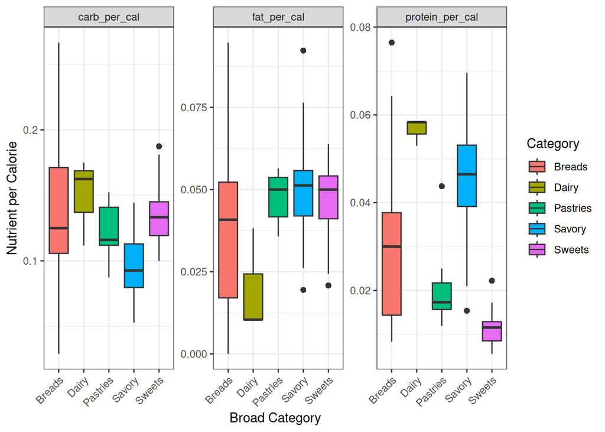

```r
pacman::p_load(ggplot2)
pacman::p_load(dplyr)
df_ratios <- df %>%
  mutate(
    protein_per_cal = Protein_g / Calories,
    fat_per_cal = Fat_g / Calories,
    carb_per_cal = Carb_g / Calories
  )

df_long <- df_ratios %>%
  select(broad_category, protein_per_cal, fat_per_cal, carb_per_cal) %>%
  pivot_longer(cols = c(protein_per_cal, fat_per_cal, carb_per_cal),
               names_to = "nutrient", values_to = "ratio")

ggplot(df_long, aes(x = broad_category, y = ratio, fill = broad_category)) +
  geom_boxplot(outlier.shape = 16, outlier.size = 2) +
  facet_wrap(~ nutrient, scales = "free_y") +
  theme_bw() +
  theme(axis.text.x = element_text(angle = 45, hjust = 1)) +
  labs(x = "Broad Category", y = "Nutrient per Calorie", fill = "Category")
```

### Step 5. Levene’s Test for Variance Homogeneity

Perform Levene’s test for homogeneity of variance on the macronutrient‐per‐calorie ratios across broad_category to validate the ANOVA assumptions.

```r
pacman::p_load(dplyr)
pacman::p_load(car)

df_ratios <- df %>%
  mutate(
    fat_per_cal = Fat_g / Calories,
    carb_per_cal = Carb_g / Calories,
    fiber_per_cal = Fiber_g / Calories,
    protein_per_cal = Protein_g / Calories
  )

leveneTest(fat_per_cal ~ broad_category, data = df_ratios)
```

```
## Levene's Test for Homogeneity of Variance (center = median)
##        Df F value   Pr(>F)
## group   4  4.3492 0.002669 **
##       108
## ---
## Signif. codes:  0 '***' 0.001 '**' 0.01 '*' 0.05 '.' 0.1 ' ' 1
```

```r
leveneTest(carb_per_cal ~ broad_category, data = df_ratios)
```

```
## Levene's Test for Homogeneity of Variance (center = median)
##        Df F value    Pr(>F)
## group   4  5.6871 0.0003421 ***
##       108
## ---
## Signif. codes:  0 '***' 0.001 '**' 0.01 '*' 0.05 '.' 0.1 ' ' 1
```

```r
leveneTest(fiber_per_cal ~ broad_category, data = df_ratios)
```

```
## Levene's Test for Homogeneity of Variance (center = median)
##        Df F value   Pr(>F)
## group   4  4.6958 0.001562 **
##       108
## ---
## Signif. codes:  0 '***' 0.001 '**' 0.01 '*' 0.05 '.' 0.1 ' ' 1
```

```r
leveneTest(protein_per_cal ~ broad_category, data = df_ratios)
```

```
## Levene's Test for Homogeneity of Variance (center = median)
##        Df F value    Pr(>F)
## group   4  8.1269 9.103e-06 ***
##       108
## ---
## Signif. codes:  0 '***' 0.001 '**' 0.01 '*' 0.05 '.' 0.1 ' ' 1
```

### Step 6. Check ANOVA residuals' normality with QQ and Shapiro-Wilk

Check the normality of ANOVA residuals for each macronutrient‐per‐calorie model by generating QQ plots and running Shapiro‐Wilk tests.

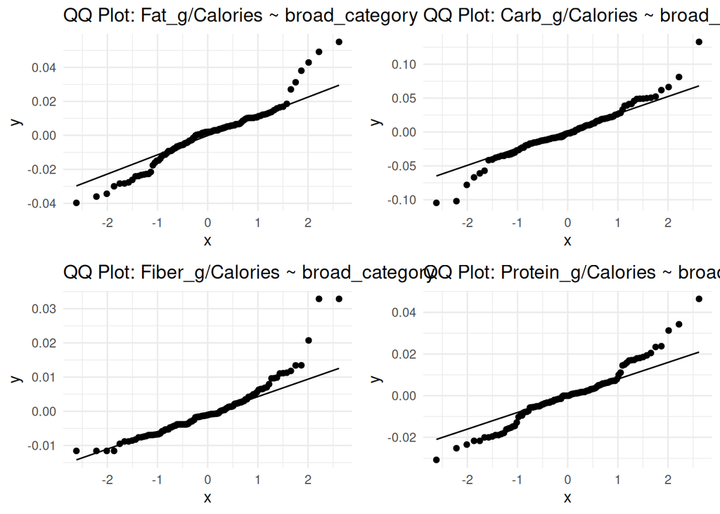

```r
pacman::p_load(ggplot2)
pacman::p_load(gridExtra)

models <- list(
  fat = aov(Fat_g / Calories ~ broad_category, data = df),
  carb = aov(Carb_g / Calories ~ broad_category, data = df),
  fiber = aov(Fiber_g / Calories ~ broad_category, data = df),
  protein = aov(Protein_g / Calories ~ broad_category, data = df)
)

qq_plots <- lapply(models, function(m) {
  res <- residuals(m)
  ggplot(data.frame(res), aes(sample = res)) +
    stat_qq() +
    stat_qq_line() +
    ggtitle(paste0("QQ Plot: ", deparse(m$call[[2]]))) +
    theme_minimal()
})

do.call(grid.arrange, c(qq_plots, ncol = 2))
```

```r
shapiro_results <- lapply(models, function(m) {
  shapiro.test(residuals(m))
})

shapiro_results
```

```
## $fat
##
##  Shapiro-Wilk normality test
##
## data:  residuals(m)
## W = 0.94713, p-value = 0.0002159
##
##
## $carb
##
##  Shapiro-Wilk normality test
##
## data:  residuals(m)
## W = 0.95926, p-value = 0.001653
##
##
## $fiber
##
##  Shapiro-Wilk normality test
##
## data:  residuals(m)
## W = 0.8727, p-value = 2.103e-08
##
##
## $protein
##
##  Shapiro-Wilk normality test
##
## data:  residuals(m)
## W = 0.95996, p-value = 0.001871
```

### Step 7. Top Healthy Items by Category and Score

Find the healthiest few items ('item') by 'broad_catgory' where healthy means the highest 'fiber_per_cal' and highest 'protein_per_cal'. Create a health score column to hold this metric.

```r
pacman::p_load(dplyr)

health_scoring <- df %>%
  mutate(
    fiber_per_cal = Fiber_g / Calories,
    protein_per_cal = Protein_g / Calories,
    health_score = fiber_per_cal + protein_per_cal
  ) %>%
  group_by(broad_category) %>%
  slice_max(order_by = health_score, n = 3, with_ties = FALSE) %>%
  select(broad_category, Item, fiber_per_cal, protein_per_cal, health_score) %>%
  arrange(broad_category, desc(health_score))

print(health_scoring)
```

```
## # A tibble: 15 × 5
## # Groups:   broad_category [5]
##    broad_category Item                fiber_per_cal protein_per_cal health_score
##    <chr>          <chr>                       <dbl>           <dbl>        <dbl>
##  1 Breads         Chicken & Quinoa P…       0.0214           0.0643       0.0857
##  2 Breads         Sous Vide Egg Bite…       0.00588          0.0765       0.0824
##  3 Breads         Multigrain Bagel          0.0229           0.0486       0.0714
##  4 Dairy          Berry Trio Yogurt         0.0125           0.0583       0.0708
##  5 Dairy          Fresh Blueberries …       0.00833          0.0583       0.0667
##  6 Dairy          Lemon Chiffon Yogu…       0                0.0529       0.0529
##  7 Pastries       Ham & Cheese Crois…       0.00312          0.0438       0.0469
##  8 Pastries       Almond Croissant          0.00732          0.0244       0.0317
##  9 Pastries       Cheese Danish             0.00312          0.025        0.0281
## 10 Savory         Spinach Feta & Cag…       0.0207           0.0655       0.0862
## 11 Savory         Certified Gluten-F…       0.0214           0.0643       0.0857
## 12 Savory         Smoked Turkey Prot…       0.0139           0.0667       0.0806
## 13 Sweets         Peanut Butter Cup …       0.00833          0.0222       0.0306
## 14 Sweets         Oatmeal Cookie            0.0103           0.0172       0.0276
## 15 Sweets         Chewy Chocolate Co…       0.0118           0.0118       0.0235
```

```r
health_scoring %>%
  arrange(desc(health_score)) %>%
  select(Item, health_score)
```

```
## # A tibble: 15 × 3
## # Groups:   broad_category [5]
##    broad_category Item                                              health_score
##    <chr>          <chr>                                                    <dbl>
##  1 Savory         Spinach Feta & Cage Free Egg White Breakfast Wrap       0.0862
##  2 Breads         Chicken & Quinoa Protein Bowl with Black Beans a…       0.0857
##  3 Savory         Certified Gluten-Free Breakfast Sandwich                0.0857
##  4 Breads         Sous Vide Egg Bites: Egg White & Red Pepper             0.0824
##  5 Savory         Smoked Turkey Protein Box                               0.0806
##  6 Breads         Multigrain Bagel                                        0.0714
##  7 Dairy          Berry Trio Yogurt                                       0.0708
##  8 Dairy          Fresh Blueberries and Honey Greek Yogurt Parfait        0.0667
##  9 Dairy          Lemon Chiffon Yogurt                                    0.0529
## 10 Pastries       Ham & Cheese Croissant                                  0.0469
## 11 Pastries       Almond Croissant                                        0.0317
## 12 Sweets         Peanut Butter Cup Cookie                                0.0306
## 13 Pastries       Cheese Danish                                           0.0281
## 14 Sweets         Oatmeal Cookie                                          0.0276
## 15 Sweets         Chewy Chocolate Cookie                                  0.0235
```

## Files:

Uploaded: ‘agent_prompts.csv’; ‘data2.csv’; ‘diamonds.csv’; ‘iris.csv’; ‘LLMs.csv’; ‘mpg.csv’; ‘mtcars.csv’; ‘RNAseq.csv’; ‘starbucks_menu_nutrition_food.csv’

## User provided background info:

The data: starbucks food menu nutrition. the question to answer: Menu Category Optimization: How do different food categories compare nutritionally? You have distinct categories (bagels, croissants, muffins, scones, cookies, danish). Investigate: Which categories offer the best nutritional value per calorie? Average macronutrient profiles by food type (are all croissants high-fat? all bagels high-carb?). Identify the “healthiest” and “least healthy” categories based on multiple criteria, Compare portion standardization across categories

## AI-generated summary

We started with Starbucks’ food-menu nutrition file (“starbucks_menu_nutrition_food.csv”), focusing on calories, fat, carbs, fiber, and protein per item. Our goal was to compare nutritional value across major food types, identify which categories and items are “healthiest,” and validate statistical assumptions.

Main Steps:

1. Data Preparation  
   • Read the CSV and inspected the first five rows.  
   • Added a ‘category’ column via pattern matching on item names (bagels, croissants, muffins, scones, cookies, danish, etc.).  
   • Created ‘broad_category’ by grouping similar categories into Sweets, Pastries, Breads, Savory, and Dairy.
2. Derived Metrics  
   • Computed macronutrient‐per‐calorie ratios: fat_per_cal, carb_per_cal, fiber_per_cal, protein_per_cal.  
   • Ran one‐way ANOVAs on each ratio by broad_category.  
   • Performed Tukey HSD post‐hoc tests to see which category pairs differ significantly in each ratio.
3. Diagnostic Checks  
   • Boxplots: Visualized ratio distributions and outliers by broad_category.  
   • Levene’s test: Found significant heterogeneity of variances across categories for all ratios (p < 0.01).  
   • QQ plots and Shapiro‐Wilk tests: Detected departures from normality in fat and fiber residuals (p < 0.001), modest deviations for carbs and protein.
4. Health‐Score Ranking  
   • Defined health_score = fiber_per_cal + protein_per_cal.  
   • For each broad_category, selected the top three items by health_score, and listed overall top-ranked items.

*AI can be wrong. Check carefully.* Using Datably 0.50 with o4-mini Azure . 4.1-nano Azure for less essential steps.